# Njoroge et al 2021 Meta-analysis MS script

### 2.6.4 Fauna effects in diffrent ecosystem types

#### 2.6.4.1 Create new data sets

First we create a data frame for each of the ecosystem type

```r
forest<- litmeta[litmeta$eco_type == "Forest", ]
grassland<- litmeta[litmeta$eco_type == "Grassland", ]
plantation<- litmeta[litmeta$eco_type == "Plantation", ]
shrubland<- litmeta[litmeta$eco_type == "Shrubland", ]
dim(forest)
dim(grassland)
dim(plantation)
dim(shrubland)
```

```
## [1] 594  56
## [1] 61 56
## [1] 156  56
## [1] 56 56
```

#### 2.6.4.2 Calculate the effect size based on the fauna status per ecosystem

```r
f_fauna<-rma(yi, vi, data = forest, subset = (Fauna_available=="present"))
g_fauna<-rma(yi, vi, data = grassland, subset = (Fauna_available=="present"))
p_fauna<-rma(yi, vi, data = plantation, subset = (Fauna_available=="present"))
s_fauna<-rma(yi, vi, data = shrubland, subset = (Fauna_available=="present"))
f_fauna
g_fauna
p_fauna
s_fauna

f_fauna_none<-rma(yi, vi, data = forest, subset = (Fauna_available=="absent"))
g_fauna_none<-rma(yi, vi, data = grassland, subset = (Fauna_available=="absent"))
p_fauna_none<-rma(yi, vi, data = plantation, subset = (Fauna_available=="absent"))
s_fauna_none<-rma(yi, vi, data = shrubland, subset = (Fauna_available=="absent"))
f_fauna_none
g_fauna_none
p_fauna_none
s_fauna_none
```

```
##
## Random-Effects Model (k = 203; tau^2 estimator: REML)
##
## tau^2 (estimated amount of total heterogeneity): 0.0332 (SE = 0.0041)
## tau (square root of estimated tau^2 value):      0.1823
## I^2 (total heterogeneity / total variability):   99.95%
## H^2 (total variability / sampling variability):  2206.57
##
## Test for Heterogeneity:
## Q(df = 202) = 600518.4067, p-val < .0001
##
## Model Results:
##
## estimate      se    zval    pval    ci.lb   ci.ub
##   0.0281  0.0145  1.9426  0.0521  -0.0003  0.0565  .
##
## ---
## Signif. codes:  0 '***' 0.001 '**' 0.01 '*' 0.05 '.' 0.1 ' ' 1
##
##
## Random-Effects Model (k = 15; tau^2 estimator: REML)
##
## tau^2 (estimated amount of total heterogeneity): 0.0682 (SE = 0.0273)
## tau (square root of estimated tau^2 value):      0.2611
## I^2 (total heterogeneity / total variability):   100.00%
## H^2 (total variability / sampling variability):  7864747.54
##
## Test for Heterogeneity:
## Q(df = 14) = 30223925.6615, p-val < .0001
##
## Model Results:
##
## estimate      se    zval    pval   ci.lb   ci.ub
##   0.4745  0.0696  6.8146  <.0001  0.3380  0.6109  ***
##
## ---
## Signif. codes:  0 '***' 0.001 '**' 0.01 '*' 0.05 '.' 0.1 ' ' 1
##
##
## Random-Effects Model (k = 49; tau^2 estimator: REML)
```

[output cut: 96 more lines]

```
## tau^2 (estimated amount of total heterogeneity): 0.0091 (SE = 0.0023)
## tau (square root of estimated tau^2 value):      0.0955
## I^2 (total heterogeneity / total variability):   95.96%
## H^2 (total variability / sampling variability):  24.78
##
## Test for Heterogeneity:
## Q(df = 48) = 376.9601, p-val < .0001
##
## Model Results:
##
## estimate      se    zval    pval    ci.lb   ci.ub
##   0.0268  0.0153  1.7502  0.0801  -0.0032  0.0568  .
##
## ---
## Signif. codes:  0 '***' 0.001 '**' 0.01 '*' 0.05 '.' 0.1 ' ' 1
```

#### 2.6.4.3 Estimated effect size based on the ecosystem types

```r
res.forest <- rma(yi, vi, data = litmeta, subset = (eco_type=="Forest"))
res.grassland <- rma(yi, vi, data = litmeta, subset = (eco_type=="Grassland"))
res.plantation <- rma(yi, vi, data = litmeta, subset = (eco_type=="Plantation"))
res.shrubland <- rma(yi, vi, data = litmeta, subset = (eco_type=="Shrubland"))
res.forest
res.grassland
res.plantation
res.shrubland
```

[output not shown]

#### 2.6.4.4 Forest plot

We plot the forest plot

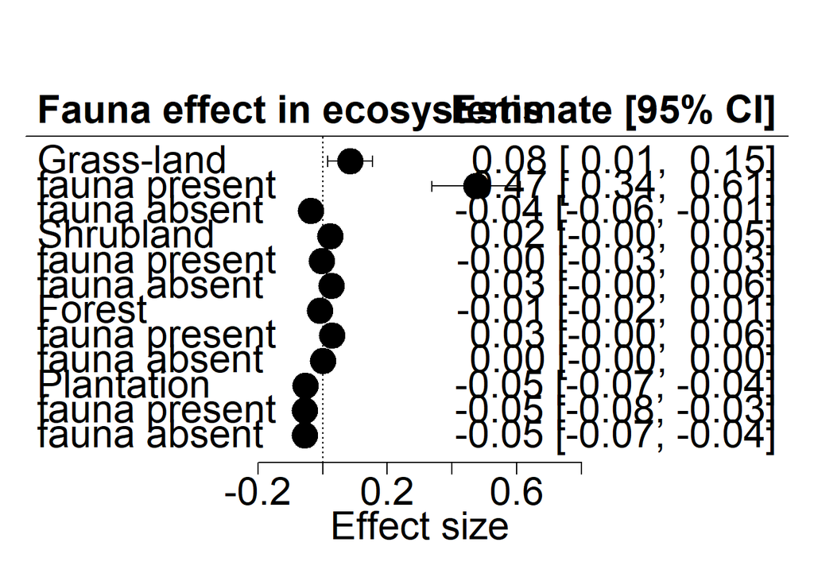

```r
estimates <- c(coef(res.grassland),coef(g_fauna),coef(g_fauna_none), coef(res.shrubland), coef(s_fauna),coef(s_fauna_none),coef(res.forest), coef(f_fauna),coef(f_fauna_none),coef(res.plantation), coef(p_fauna),coef(p_fauna))
variances <- c(vcov(res.grassland), vcov(g_fauna),vcov(g_fauna_none),vcov(res.shrubland),vcov(s_fauna),vcov(s_fauna_none),vcov(res.forest),vcov(f_fauna),vcov(f_fauna_none),vcov(res.plantation), vcov(p_fauna), vcov(p_fauna_none))
labels <- c("Grass-land","fauna present","fauna absent","Shrubland","fauna present","fauna absent","Forest","fauna present","fauna absent","Plantation","fauna present","fauna absent")
forest(estimates, variances, slab=labels,header = "Fauna effect in ecosystems",col ="black",xlab = "Effect size", cex=2,pch = 19, psize=1.5)
```

Manually plot the above forest plots using ggplot since its easier to work on the visual impact of the plot (Figure 4 c).

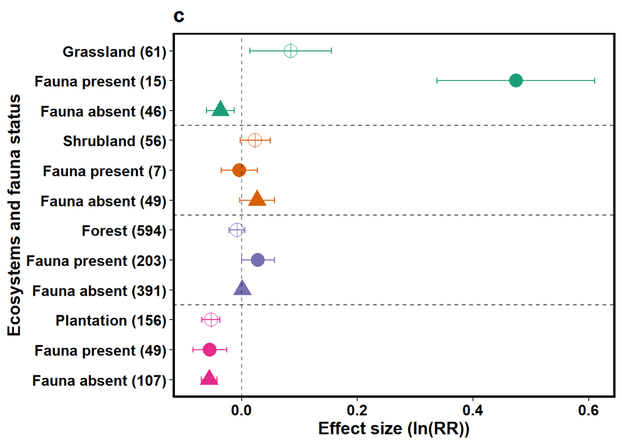

```
##  [1] 1 2 3 1 2 3 1 2 3 1 2 3
## Levels: 1 2 3
```

```r
dat10 <- data.frame(
  labels <- c("Grassland (61)","Fauna present (15)","Fauna absent (46)","Shrubland (56)","Fauna present (7)","Fauna absent (49)","Forest (594)","Fauna present (203)","Fauna absent (391)","Plantation (156)","Fauna present (49)","Fauna absent (107)"),
  point_est = c( 0.0848 , 0.4745  ,-0.0368, 0.0236,-0.0037, 0.0268,-0.0079,0.0281,0.0010, -0.0531,-0.0549,-0.0562   ),
  lb_ci = c(0.0147,  0.3380 ,-0.0610 , -0.0027,-0.0349 ,-0.0032,-0.0218,-0.0003,-0.0014,-0.0686,-0.0840,-0.0696     ),
  ub_ci = c(0.1550,0.6109  ,  -0.0127, 0.0499 , 0.0275, 0.0568, 0.0059,0.0565,0.0033,-0.0376,  -0.0258, -0.0427 ),
  group = c(1,2,3,1,2,3,1,2,3,1,2,3),
  ecosystem= c(1,1,1,2,2,2,3,3,3,4,4,4)
)
dat10$label <- factor(dat10$label, levels = dat10$label)
as.factor(dat10$group)
plot10 <- ggplot(dat10, aes(x=point_est, y=label, shape=as.factor(group), color=as.factor(ecosystem)))  + scale_shape_manual(values = c(10, 16, 17))+
  scale_color_brewer(palette="Dark2")+theme(legend.position="none") +
  geom_point(size=5) + scale_y_discrete(limits = rev(levels(dat10$label))) + geom_vline(xintercept=0, color="black", linetype="dashed", alpha=.5) +
  geom_errorbarh(aes(xmin=lb_ci, xmax=ub_ci), height=.2) +geom_hline(yintercept = c(3.5,6.5,9.5),color="black", linetype="dashed", alpha=.7)+
  ggtitle("c")+
  ylab("Ecosystems and fauna status") + xlab("Effect size (ln(RR))") + theme(text = element_text(size = 14,face="bold"), panel.background = element_blank(),
                                                   panel.grid.major = element_blank(),
                                                   panel.grid.minor = element_blank(),
                                                   axis.line = element_line(colour = "black"),
                                                   panel.border = element_rect(colour = "black", fill=NA, size=1.5)) +  theme(axis.text = element_text(family = "palatino", colour = "black", size = (12)))
plot10
```

#### 2.6.4.5 Model for different ecosystems with fauna availability as the moderator

```r
ffauna<- rma (yi = yi, vi = vi, mod = ~Fauna_available, method = "REML", data = forest )
gfauna<- rma (yi = yi, vi = vi, mod = ~Fauna_available, method = "REML", data = grassland )
pfauna<- rma (yi = yi, vi = vi, mod = ~Fauna_available, method = "REML", data = plantation)
sfauna<- rma (yi = yi, vi = vi, mod = ~Fauna_available, method = "REML", data = shrubland )
summary(ffauna)
summary(gfauna)
summary(pfauna)
summary(sfauna)
```

```
##
## Mixed-Effects Model (k = 594; tau^2 estimator: REML)
##
##    logLik   deviance        AIC        BIC       AICc
##   75.6281  -151.2562  -145.2562  -132.1057  -145.2154
##
## tau^2 (estimated amount of residual heterogeneity):     0.0159 (SE = 0.0014)
## tau (square root of estimated tau^2 value):             0.1262
## I^2 (residual heterogeneity / unaccounted variability): 99.78%
## H^2 (unaccounted variability / sampling variability):   460.37
## R^2 (amount of heterogeneity accounted for):            1.45%
##
## Test for Residual Heterogeneity:
## QE(df = 592) = 601865.7519, p-val < .0001
##
## Test of Moderators (coefficient 2):
## QM(df = 1) = 15.8583, p-val < .0001
##
## Model Results:
##
##                         estimate      se     zval    pval    ci.lb    ci.ub
## intrcpt                  -0.0322  0.0093  -3.4529  0.0006  -0.0505  -0.0139
## Fauna_availablepresent    0.0567  0.0142   3.9822  <.0001   0.0288   0.0846
##
## intrcpt                 ***
## Fauna_availablepresent  ***
##
## ---
## Signif. codes:  0 '***' 0.001 '**' 0.01 '*' 0.05 '.' 0.1 ' ' 1
##
##
## Mixed-Effects Model (k = 61; tau^2 estimator: REML)
##
##   logLik  deviance       AIC       BIC      AICc
##  26.7722  -53.5444  -47.5444  -41.3118  -47.1080
##
## tau^2 (estimated amount of residual heterogeneity):     0.0160 (SE = 0.0033)
## tau (square root of estimated tau^2 value):             0.1263
## I^2 (residual heterogeneity / unaccounted variability): 100.00%
## H^2 (unaccounted variability / sampling variability):   437893.10
```

[output cut: 61 more lines]

```
##
## Test for Residual Heterogeneity:
## QE(df = 54) = 390.4117, p-val < .0001
##
## Test of Moderators (coefficient 2):
## QM(df = 1) = 0.5932, p-val = 0.4412
##
## Model Results:
##
##                         estimate      se     zval    pval    ci.lb   ci.ub
## intrcpt                   0.0277  0.0144   1.9149  0.0555  -0.0007  0.0560  .
## Fauna_availablepresent   -0.0304  0.0394  -0.7702  0.4412  -0.1077  0.0469
##
## ---
## Signif. codes:  0 '***' 0.001 '**' 0.01 '*' 0.05 '.' 0.1 ' ' 1
```

#### 2.6.4.6 Model with species diversity as a moderator

##### 2.6.4.6.1 Species effects in different climatic region

```r
tropics<- litmeta[litmeta$climatic_region == "Tropics", ]
subtropics<- litmeta[litmeta$climatic_region == "Sub-tropics", ]
temperate<- litmeta[litmeta$climatic_region == "Temperate", ]
metropsp<- rma (yi = yi, vi = vi, mod = ~sp_div_in_mixture, method = "REML", data = tropics )
metsubsp<- rma (yi = yi, vi = vi, mod = ~sp_div_in_mixture, method = "REML", data = subtropics )
mettempsp<- rma (yi = yi, vi = vi, mod = ~sp_div_in_mixture, method = "REML", data = temperate)
summary(metropsp)
summary(metsubsp)
summary(mettempsp)
```

```
##
## Mixed-Effects Model (k = 120; tau^2 estimator: REML)
##
##   logLik  deviance       AIC       BIC      AICc
##  -0.9453    1.8907    7.8907   16.2027    8.1012
##
## tau^2 (estimated amount of residual heterogeneity):     0.0346 (SE = 0.0050)
## tau (square root of estimated tau^2 value):             0.1859
## I^2 (residual heterogeneity / unaccounted variability): 99.85%
## H^2 (unaccounted variability / sampling variability):   677.00
## R^2 (amount of heterogeneity accounted for):            0.00%
##
## Test for Residual Heterogeneity:
## QE(df = 118) = 9118.3145, p-val < .0001
##
## Test of Moderators (coefficient 2):
## QM(df = 1) = 0.1642, p-val = 0.6853
##
## Model Results:
##
##                    estimate      se     zval    pval    ci.lb   ci.ub
## intrcpt              0.0752  0.0591   1.2727  0.2031  -0.0406  0.1911
## sp_div_in_mixture   -0.0091  0.0225  -0.4052  0.6853  -0.0532  0.0350
##
## ---
## Signif. codes:  0 '***' 0.001 '**' 0.01 '*' 0.05 '.' 0.1 ' ' 1
##
##
## Mixed-Effects Model (k = 243; tau^2 estimator: REML)
##
##   logLik  deviance       AIC       BIC      AICc
## -22.4586   44.9172   50.9172   61.3716   51.0185
##
## tau^2 (estimated amount of residual heterogeneity):     0.0392 (SE = 0.0051)
## tau (square root of estimated tau^2 value):             0.1980
## I^2 (residual heterogeneity / unaccounted variability): 100.00%
## H^2 (unaccounted variability / sampling variability):   236208.64
## R^2 (amount of heterogeneity accounted for):            0.00%
##
## Test for Residual Heterogeneity:
```

[output cut: 25 more lines]

```
##
## Test for Residual Heterogeneity:
## QE(df = 502) = 880647.5135, p-val < .0001
##
## Test of Moderators (coefficient 2):
## QM(df = 1) = 5.6975, p-val = 0.0170
##
## Model Results:
##
##                    estimate      se     zval    pval    ci.lb    ci.ub
## intrcpt              0.0024  0.0169   0.1408  0.8880  -0.0308   0.0356
## sp_div_in_mixture   -0.0160  0.0067  -2.3869  0.0170  -0.0291  -0.0029  *
##
## ---
## Signif. codes:  0 '***' 0.001 '**' 0.01 '*' 0.05 '.' 0.1 ' ' 1
```

##### 2.6.4.6.2 Species effects in different ecosystems

```r
spforest<- rma (yi = yi, vi = vi, mod = ~sp_div_in_mixture, method = "REML", data = forest )
spgrassland<- rma (yi = yi, vi = vi, mod = ~sp_div_in_mixture, method = "REML", data = grassland )
spplantation<- rma (yi = yi, vi = vi, mod = ~sp_div_in_mixture, method = "REML", data = plantation)
spshrubland<- rma (yi = yi, vi = vi, mod = ~sp_div_in_mixture, method = "REML", data = shrubland )
summary(spforest)
summary(spgrassland)
summary(spplantation)
summary(spshrubland)
```

```
##
## Mixed-Effects Model (k = 594; tau^2 estimator: REML)
##
##    logLik   deviance        AIC        BIC       AICc
##   68.3309  -136.6617  -130.6617  -117.5112  -130.6209
##
## tau^2 (estimated amount of residual heterogeneity):     0.0162 (SE = 0.0015)
## tau (square root of estimated tau^2 value):             0.1273
## I^2 (residual heterogeneity / unaccounted variability): 99.79%
## H^2 (unaccounted variability / sampling variability):   474.92
## R^2 (amount of heterogeneity accounted for):            0.00%
##
## Test for Residual Heterogeneity:
## QE(df = 592) = 582974.3991, p-val < .0001
##
## Test of Moderators (coefficient 2):
## QM(df = 1) = 0.7057, p-val = 0.4009
##
## Model Results:
##
##                    estimate      se     zval    pval    ci.lb   ci.ub
## intrcpt              0.0052  0.0172   0.3025  0.7623  -0.0285  0.0389
## sp_div_in_mixture   -0.0050  0.0059  -0.8400  0.4009  -0.0165  0.0066
##
## ---
## Signif. codes:  0 '***' 0.001 '**' 0.01 '*' 0.05 '.' 0.1 ' ' 1
##
##
## Mixed-Effects Model (k = 61; tau^2 estimator: REML)
##
##   logLik  deviance       AIC       BIC      AICc
##  -2.8545    5.7090   11.7090   17.9416   12.1453
##
## tau^2 (estimated amount of residual heterogeneity):     0.0595 (SE = 0.0116)
## tau (square root of estimated tau^2 value):             0.2438
## I^2 (residual heterogeneity / unaccounted variability): 100.00%
## H^2 (unaccounted variability / sampling variability):   1451925.95
## R^2 (amount of heterogeneity accounted for):            19.34%
##
## Test for Residual Heterogeneity:
```

[output cut: 52 more lines]

```
##
## Test for Residual Heterogeneity:
## QE(df = 54) = 388.5222, p-val < .0001
##
## Test of Moderators (coefficient 2):
## QM(df = 1) = 0.3744, p-val = 0.5406
##
## Model Results:
##
##                    estimate      se     zval    pval    ci.lb   ci.ub
## intrcpt              0.0706  0.0781   0.9046  0.3657  -0.0824  0.2236
## sp_div_in_mixture   -0.0216  0.0353  -0.6119  0.5406  -0.0909  0.0476
##
## ---
## Signif. codes:  0 '***' 0.001 '**' 0.01 '*' 0.05 '.' 0.1 ' ' 1
```

##### 2.6.4.6.3 Effects size based of species diversity across ecosystems

Here we estimate the effect size based on the species richness levels in different ecosystems

```r
f_spe_rich2<-rma(yi, vi, data = forest, subset = (species_richness=="two"))
f_spe_rich3<-rma(yi, vi, data = forest, subset = (species_richness=="three"))
f_spe_rich4<-rma(yi, vi, data = forest, subset = (species_richness=="four"))
f_spe_rich5<-rma(yi, vi, data = forest, subset = (species_richness=="five"))
f_spe_rich6<-rma(yi, vi, data = forest, subset = (species_richness=="six"))
f_spe_rich12<-rma(yi, vi, data = forest, subset = (species_richness=="twelve"))
f_spe_rich2
f_spe_rich3
f_spe_rich4
f_spe_rich5
f_spe_rich6
f_spe_rich12

s_spe_rich2<-rma(yi, vi, data = shrubland, subset = (species_richness=="two"))
s_spe_rich3<-rma(yi, vi, data = shrubland, subset = (species_richness=="three"))
s_spe_rich2
s_spe_rich3
g_spe_rich2<-rma(yi, vi, data = grassland, subset = (species_richness=="two"))
g_spe_rich3<-rma(yi, vi, data = grassland, subset = (species_richness=="three"))
g_spe_rich4<-rma(yi, vi, data = grassland, subset = (species_richness=="four"))
g_spe_rich2
g_spe_rich3
g_spe_rich4
p_spe_rich2<-rma(yi, vi, data = plantation, subset = (species_richness=="two"))
p_spe_rich3<-rma(yi, vi, data = plantation, subset = (species_richness=="three"))
p_spe_rich4<-rma(yi, vi, data = plantation, subset = (species_richness=="four"))
p_spe_rich2
p_spe_rich3
p_spe_rich4
```

```
##
## Random-Effects Model (k = 396; tau^2 estimator: REML)
##
## tau^2 (estimated amount of total heterogeneity): 0.0180 (SE = 0.0019)
## tau (square root of estimated tau^2 value):      0.1340
## I^2 (total heterogeneity / total variability):   99.53%
## H^2 (total variability / sampling variability):  213.44
##
## Test for Heterogeneity:
## Q(df = 395) = 9775.6598, p-val < .0001
##
## Model Results:
##
## estimate      se    zval    pval    ci.lb   ci.ub
##   0.0031  0.0090  0.3397  0.7340  -0.0146  0.0207
##
## ---
## Signif. codes:  0 '***' 0.001 '**' 0.01 '*' 0.05 '.' 0.1 ' ' 1
##
##
## Random-Effects Model (k = 77; tau^2 estimator: REML)
##
## tau^2 (estimated amount of total heterogeneity): 0.0167 (SE = 0.0036)
## tau (square root of estimated tau^2 value):      0.1292
## I^2 (total heterogeneity / total variability):   99.96%
## H^2 (total variability / sampling variability):  2661.39
##
## Test for Heterogeneity:
## Q(df = 76) = 529767.5449, p-val < .0001
##
## Model Results:
##
## estimate      se     zval    pval    ci.lb    ci.ub
##  -0.0564  0.0176  -3.2011  0.0014  -0.0909  -0.0219  **
##
## ---
## Signif. codes:  0 '***' 0.001 '**' 0.01 '*' 0.05 '.' 0.1 ' ' 1
##
##
## Random-Effects Model (k = 33; tau^2 estimator: REML)
```

[output cut: 210 more lines]

```
## tau^2 (estimated amount of total heterogeneity): 0.0002 (SE = 0.0001)
## tau (square root of estimated tau^2 value):      0.0141
## I^2 (total heterogeneity / total variability):   91.71%
## H^2 (total variability / sampling variability):  12.06
##
## Test for Heterogeneity:
## Q(df = 8) = 86.6699, p-val < .0001
##
## Model Results:
##
## estimate      se      zval    pval    ci.lb    ci.ub
##  -0.0639  0.0059  -10.8004  <.0001  -0.0755  -0.0523  ***
##
## ---
## Signif. codes:  0 '***' 0.001 '**' 0.01 '*' 0.05 '.' 0.1 ' ' 1
```

##### 2.6.4.6.4 Forest plot

To visually look at the results, we use a forest plot

[figure not shown]

```r
estimates <- c(coef(res.forest),coef(f_spe_rich2), coef(f_spe_rich3), coef(f_spe_rich4),coef(f_spe_rich5), coef(f_spe_rich6),coef(f_spe_rich12),coef(res.shrubland),coef(s_spe_rich2), coef(s_spe_rich3),coef(res.grassland),coef(g_spe_rich2), coef(g_spe_rich3),coef(g_spe_rich4),coef(res.plantation),coef(p_spe_rich2), coef(p_spe_rich3), coef(p_spe_rich4))
variances <- c(vcov(res.forest),vcov(f_spe_rich2), vcov(f_spe_rich3), vcov(f_spe_rich4),vcov(f_spe_rich5),vcov(f_spe_rich6),vcov(f_spe_rich12), vcov(res.shrubland),vcov(s_spe_rich2), vcov(s_spe_rich3),vcov(res.grassland),vcov(g_spe_rich2), vcov(g_spe_rich3), vcov(g_spe_rich4),vcov(res.plantation),vcov(f_spe_rich2), vcov(f_spe_rich3), vcov(f_spe_rich4))
labels <- c("Forest","Two (396)", "Three (77)", "Four (33)","Five (33)","Six (51)","Twelve (4)","Shrubland", "Two (47)","Three (9)", "Grassland", "Two (53)","Three (3)","Four (1)", "Plantation", "Two (113)","Three (34)", "Four (9)")
forest(estimates, variances, slab=labels,col= "black" ,header = "Species richness",pch=19,cex=2,xlab = "Effect Size (ln(RR))",psize=1.5)
```

We also manually plot the above forest plots using ggplot2 (Figure S2 b).

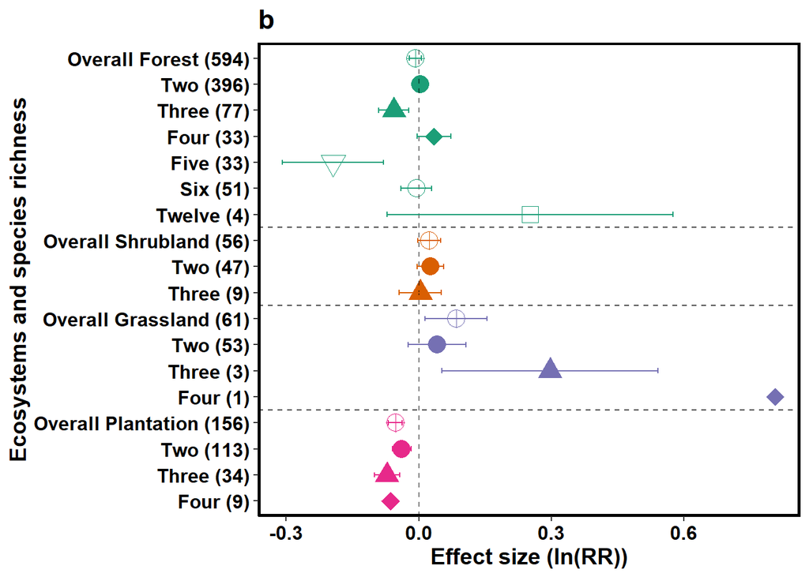

```
##  [1] 1  2  3  4  5  6  12 1  2  3  1  2  3  4  1  2  3  4
## Levels: 1 2 3 4 5 6 12
```

```r
dat11 <- data.frame(
  labels <- c("Overall Forest (594)","Two (396)", "Three (77)", "Four (33)","Five (33)","Six (51)","Twelve (4)"," Overall Shrubland (56)", "Two (47)","Three (9)", "Overall Grassland (61)", "Two (53)","Three (3)","Four (1)", "Overall Plantation (156)", "Two (113)","Three (34)", "Four (9)"),
  point_est = c( -0.0079 ,0.0031, -0.0564,0.0343,-0.1938,-0.0054,0.2516, 0.0236,0.0267,0.0037, 0.0848,0.0413,0.2966,0.8060,-0.0531, -0.0384,-0.0720,-0.0639),
  lb_ci = c(  -0.0218 ,-0.0146, -0.0909,-0.0039,-0.3077, -0.0407,-0.0716, -0.0027,-0.0036,-0.0441, 0.0147 ,-0.0238,0.0518, 0.8059,-0.0686,-0.0597,-0.1006,-0.0755  ),
  ub_ci = c(0.0059,0.0207,-0.0219,0.0724,-0.0799, 0.0298,0.5748,0.0499 , 0.0570,0.0515,0.1550, 0.1064,0.5413, 0.8062,-0.0376 ,-0.0170,-0.0435,-0.0523 ),
  group = c(1,2,3,4,5,6,12,1,2,3,1,2,3,4,1,2,3,4),
  ecosystem= c(1,1,1,1,1,1,1,2,2,2,3,3,3,3,4,4,4,4)
)
dat11$label <- factor(dat11$label, levels = dat11$label)
as.factor(dat11$group)
plot11 <- ggplot(dat11, aes(x=point_est, y=label, shape=as.factor(group),color=as.factor(ecosystem))) +
  theme(legend.position="none") +scale_shape_manual(values = c(10, 16, 17,18,25,21,22))+scale_color_brewer(palette="Dark2")+
  geom_point(size=5) + scale_y_discrete(limits = rev(levels(dat11$label))) + geom_vline(xintercept=0, color="black", linetype="dashed", alpha=.5) +
  geom_errorbarh(aes(xmin=lb_ci, xmax=ub_ci), height=.2) +
  ggtitle("b")+ geom_hline(yintercept = c(4.5,8.5,11.5),color="black", linetype="dashed", alpha=.7)+
  ylab("Ecosystems and species richness") + xlab("Effect size (ln(RR))") + theme(text = element_text(size = 14,face="bold"), panel.background = element_blank(),
                                                                                 panel.grid.major = element_blank(),
                                                                                 panel.grid.minor = element_blank(),
                                                                                 axis.line = element_line(colour = "black"),
                                                                                 panel.border = element_rect(colour = "black", fill=NA, size=1.5)) +  theme(axis.text = element_text(family = "palatino", colour = "black", size = (12)))
plot11
```

##### 2.6.4.6.5 Estimate the effect size at species richness levels in different climatic regions

```r
temp_spe_rich2<-rma(yi, vi, data = temperate, subset = (species_richness=="two"))
temp_spe_rich3<-rma(yi, vi, data = temperate, subset = (species_richness=="three"))
temp_spe_rich4<-rma(yi, vi, data = temperate, subset = (species_richness=="four"))
temp_spe_rich5<-rma(yi, vi, data = temperate, subset = (species_richness=="five"))
temp_spe_rich6<-rma(yi, vi, data = temperate, subset = (species_richness=="six"))
temp_spe_rich12<-rma(yi, vi, data = temperate, subset = (species_richness=="twelve"))
temp_spe_rich2
temp_spe_rich3
temp_spe_rich4
temp_spe_rich5
temp_spe_rich6
temp_spe_rich12
sub_spe_rich2<-rma(yi, vi, data = subtropics, subset = (species_richness=="two"))
sub_spe_rich3<-rma(yi, vi, data = subtropics, subset = (species_richness=="three"))
sub_spe_rich4<-rma(yi, vi, data = subtropics, subset = (species_richness=="four"))
sub_spe_rich5<-rma(yi, vi, data = subtropics, subset = (species_richness=="five"))
sub_spe_rich6<-rma(yi, vi, data = subtropics, subset = (species_richness=="six"))
sub_spe_rich2
sub_spe_rich3
sub_spe_rich4
sub_spe_rich5
sub_spe_rich6
trop_spe_rich2<-rma(yi, vi, data = tropics, subset = (species_richness=="two"))
trop_spe_rich3<-rma(yi, vi, data = tropics, subset = (species_richness=="three"))
trop_spe_rich4<-rma(yi, vi, data = tropics, subset = (species_richness=="four"))
#trop_spe_rich5<-rma(yi, vi, data = tropics, subset = (species_richness=="five"))#k=0
trop_spe_rich6<-rma(yi, vi, data = tropics, subset = (species_richness=="six"))
#trop_spe_rich12<-rma(yi, vi, data = tropics, subset = (species_richness=="twelve"))
trop_spe_rich2
trop_spe_rich3
trop_spe_rich4
trop_spe_rich6
```

```
##
## Random-Effects Model (k = 382; tau^2 estimator: REML)
##
## tau^2 (estimated amount of total heterogeneity): 0.0062 (SE = 0.0008)
## tau (square root of estimated tau^2 value):      0.0789
## I^2 (total heterogeneity / total variability):   96.90%
## H^2 (total variability / sampling variability):  32.23
##
## Test for Heterogeneity:
## Q(df = 381) = 1799.4515, p-val < .0001
##
## Model Results:
##
## estimate      se     zval    pval    ci.lb    ci.ub
##  -0.0221  0.0061  -3.6287  0.0003  -0.0341  -0.0102  ***
##
## ---
## Signif. codes:  0 '***' 0.001 '**' 0.01 '*' 0.05 '.' 0.1 ' ' 1
##
##
## Random-Effects Model (k = 69; tau^2 estimator: REML)
##
## tau^2 (estimated amount of total heterogeneity): 0.0106 (SE = 0.0023)
## tau (square root of estimated tau^2 value):      0.1029
## I^2 (total heterogeneity / total variability):   99.96%
## H^2 (total variability / sampling variability):  2560.97
##
## Test for Heterogeneity:
## Q(df = 68) = 861185.0549, p-val < .0001
##
## Model Results:
##
## estimate      se     zval    pval    ci.lb    ci.ub
##  -0.0729  0.0141  -5.1691  <.0001  -0.1005  -0.0453  ***
##
## ---
## Signif. codes:  0 '***' 0.001 '**' 0.01 '*' 0.05 '.' 0.1 ' ' 1
##
##
## Random-Effects Model (k = 11; tau^2 estimator: REML)
```

[output cut: 229 more lines]

```
## tau^2 (estimated amount of total heterogeneity): 0.0299 (SE = 0.0438)
## tau (square root of estimated tau^2 value):      0.1729
## I^2 (total heterogeneity / total variability):   96.60%
## H^2 (total variability / sampling variability):  29.39
##
## Test for Heterogeneity:
## Q(df = 1) = 29.3926, p-val < .0001
##
## Model Results:
##
## estimate      se    zval    pval    ci.lb   ci.ub
##   0.1837  0.1243  1.4771  0.1396  -0.0600  0.4274
##
## ---
## Signif. codes:  0 '***' 0.001 '**' 0.01 '*' 0.05 '.' 0.1 ' ' 1
```

##### 2.6.4.6.6 Forest plot

We visually look at the results using forest plot.

[figure not shown]

```r
estimates <- c(coef(res.temperate),coef(temp_spe_rich2), coef(temp_spe_rich3), coef(temp_spe_rich4),coef(temp_spe_rich5), coef(temp_spe_rich6),coef(temp_spe_rich12),coef(res.subtropics),coef(sub_spe_rich2), coef(sub_spe_rich3),coef(sub_spe_rich4),coef(sub_spe_rich5), coef(sub_spe_rich6),coef(res.tropics),coef(trop_spe_rich2), coef(trop_spe_rich3),coef(trop_spe_rich4),coef(trop_spe_rich6))

variances <- c(vcov(res.temperate),vcov(temp_spe_rich2), vcov(temp_spe_rich3), vcov(temp_spe_rich4),vcov(temp_spe_rich5),vcov(temp_spe_rich6),vcov(temp_spe_rich12), vcov(res.subtropics),vcov(sub_spe_rich2), vcov(sub_spe_rich3),vcov(sub_spe_rich4),vcov(sub_spe_rich5),vcov(sub_spe_rich6),vcov(res.tropics),vcov(trop_spe_rich2), vcov(trop_spe_rich3), vcov(trop_spe_rich4),vcov(trop_spe_rich6))
labels <- c("Temperate","Two (382)", "Three (69)", "Four (11)","Five (32)","Six (6)","Twelve (4)","Subtropics", "Two (150)","Three (27)","Four (22)", "Five (1)", "Six (43)", "Tropics", "Two (77)","Three (31)", "Four (10)","Six (2)")
forest(estimates, variances, slab=labels,col= "black" ,header = "Species richness",pch=19,cex=2,xlab = "Effect Size (ln(RR))",psize=1.5)
```

We also manually plot the above forest plots using ggplot2 (Figure S2 c)

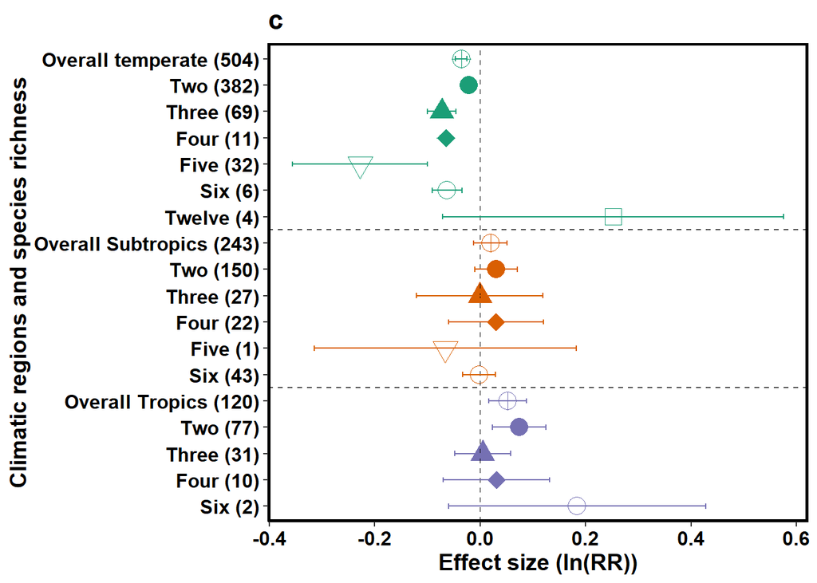

```
##  [1] 1  2  3  4  5  6  12 1  2  3  4  5  6  1  2  3  4  6
## Levels: 1 2 3 4 5 6 12
```

```r
dat12 <- data.frame(
 labels <- c("Overall temperate (504)","Two (382)", "Three (69)", "Four (11)","Five (32)","Six (6)","Twelve (4)","Overall Subtropics (243)", "Two (150)","Three (27)","Four (22)", "Five (1)", "Six (43)", "Overall Tropics (120)", "Two (77)","Three (31)", "Four (10)","Six (2)"),
  point_est = c(-0.0359,-0.0221,-0.0729,-0.0647,-0.2278, -0.0626,0.2516,0.0193,0.0300,-0.0006,0.0303,-0.0662,-0.0018, 0.0523,0.0736,0.0048,0.0310,0.1837),
  lb_ci = c(-0.0469,-0.0341,-0.1005,-0.0758,-0.3559 ,-0.0911,-0.0716,-0.0124,-0.0101,-0.1205,-0.0595,-0.3145,-0.0329,0.0168,0.0230,-0.0483,-0.0696,-0.0600),
  ub_ci = c(-0.0248,-0.0102,-0.0453,-0.0536,-0.0996,-0.0341,0.5748, 0.0509, 0.0701,0.1193,0.1202,0.1820,0.0293,0.0878,0.1242,0.0579,0.1317,0.4274),
  group = c(1,2,3,4,5,6,12,1,2,3,4,5,6,1,2,3,4,6),
  region= c(1,1,1,1,1,1,1,2,2,2,2,2,2,3,3,3,3,3)
)
dat12$label <- factor(dat12$label, levels = dat12$label)
as.factor(dat12$group)
plot12 <-  ggplot(dat12, aes(x=point_est, y=label, shape=as.factor(group),color=as.factor(region))) +
  theme(legend.position="none") +scale_shape_manual(values = c(10, 16, 17,18,25,21,22))+scale_color_brewer(palette="Dark2")+
  geom_point(size=5) + scale_y_discrete(limits = rev(levels(dat12$label))) + geom_vline(xintercept=0, color="black", linetype="dashed", alpha=.5) +
  geom_errorbarh(aes(xmin=lb_ci, xmax=ub_ci), height=.2) +
  ggtitle("c")+ geom_hline(yintercept = c(5.5,11.5),color="black", linetype="dashed", alpha=.7)+
  ylab("Climatic regions and species richness") + xlab("Effect size (ln(RR))") + theme(text = element_text(size = 14,face="bold"), panel.background = element_blank(),
                                                                                 panel.grid.major = element_blank(),
                                                                                 panel.grid.minor = element_blank(),
                                                                                 axis.line = element_line(colour = "black"),
                                                                                 panel.border = element_rect(colour = "black", fill=NA, size=1.5)) +  theme(axis.text = element_text(family = "palatino", colour = "black", size = (12)))
plot12
```

### 2.6.5 Metaregression for all variables across climatic regions and ecosysytems

#### 2.6.5.1 Carbon nitrogen ratio

```r
cntem<- rma (yi = yi, vi = vi, mod = ~Lit_Car_Nit_ratio, method = "REML", data = temperate )
cnsub<- rma (yi = yi, vi = vi, mod = ~Lit_Car_Nit_ratio, method = "REML", data = subtropics )
cntr<- rma (yi = yi, vi = vi, mod = ~Lit_Car_Nit_ratio, method = "REML", data = tropics )
cnfo<- rma (yi = yi, vi = vi, mod = ~Lit_Car_Nit_ratio, method = "REML", data = forest )
cngr<- rma (yi = yi, vi = vi, mod = ~Lit_Car_Nit_ratio, method = "REML", data = grassland )
cnpl<- rma (yi = yi, vi = vi, mod = ~Lit_Car_Nit_ratio, method = "REML", data = plantation)
cnsh<- rma (yi = yi, vi = vi, mod = ~Lit_Car_Nit_ratio, method = "REML", data = shrubland )

summary(cntem)
summary(cnsub)
summary(cntr)
summary(cnfo)
summary(cngr)
summary(cnpl)
summary(cnsh)
```

```
##
## Mixed-Effects Model (k = 399; tau^2 estimator: REML)
##
##    logLik   deviance        AIC        BIC       AICc
##  113.8375  -227.6750  -221.6750  -209.7231  -221.6139
##
## tau^2 (estimated amount of residual heterogeneity):     0.0087 (SE = 0.0011)
## tau (square root of estimated tau^2 value):             0.0934
## I^2 (residual heterogeneity / unaccounted variability): 99.74%
## H^2 (unaccounted variability / sampling variability):   382.85
## R^2 (amount of heterogeneity accounted for):            1.38%
##
## Test for Residual Heterogeneity:
## QE(df = 397) = 861044.3124, p-val < .0001
##
## Test of Moderators (coefficient 2):
## QM(df = 1) = 6.5410, p-val = 0.0105
##
## Model Results:
##
##                    estimate      se     zval    pval    ci.lb    ci.ub
## intrcpt             -0.0866  0.0180  -4.8052  <.0001  -0.1219  -0.0513  ***
## Lit_Car_Nit_ratio    0.0008  0.0003   2.5575  0.0105   0.0002   0.0014    *
##
## ---
## Signif. codes:  0 '***' 0.001 '**' 0.01 '*' 0.05 '.' 0.1 ' ' 1
##
##
## Mixed-Effects Model (k = 73; tau^2 estimator: REML)
##
##   logLik  deviance       AIC       BIC      AICc
## -15.4593   30.9186   36.9186   43.7066   37.2768
##
## tau^2 (estimated amount of residual heterogeneity):     0.0790 (SE = 0.0143)
## tau (square root of estimated tau^2 value):             0.2810
## I^2 (residual heterogeneity / unaccounted variability): 100.00%
## H^2 (unaccounted variability / sampling variability):   1772063.63
## R^2 (amount of heterogeneity accounted for):            0.00%
##
## Test for Residual Heterogeneity:
```

[output cut: 133 more lines]

```
##
## Test for Residual Heterogeneity:
## QE(df = 51) = 391.6124, p-val < .0001
##
## Test of Moderators (coefficient 2):
## QM(df = 1) = 2.7720, p-val = 0.0959
##
## Model Results:
##
##                    estimate      se     zval    pval    ci.lb   ci.ub
## intrcpt             -0.0220  0.0309  -0.7119  0.4765  -0.0825  0.0386
## Lit_Car_Nit_ratio    0.0009  0.0005   1.6649  0.0959  -0.0002  0.0019  .
##
## ---
## Signif. codes:  0 '***' 0.001 '**' 0.01 '*' 0.05 '.' 0.1 ' ' 1
```

#### 2.6.5.2 Litter P content

```r
ptem<-rma (yi = yi, vi = vi, mod = ~Lit_Pho, method = "REML", data = temperate )
psub<-rma (yi = yi, vi = vi, mod = ~Lit_Pho, method = "REML", data = subtropics )
ptr<-rma (yi = yi, vi = vi, mod = ~Lit_Pho, method = "REML", data = tropics )
pfo<-rma (yi = yi, vi = vi, mod = ~Lit_Pho, method = "REML", data = forest )
pgr<-rma (yi = yi, vi = vi, mod = ~Lit_Pho, method = "REML", data = grassland )
psh<-rma (yi = yi, vi = vi, mod = ~Lit_Pho, method = "REML", data = shrubland )
ppl<-rma (yi = yi, vi = vi, mod = ~Lit_Pho, method = "REML", data = plantation )


summary(ptem)
summary(psub)
summary(ptr)
summary(pfo)
summary(pgr)
summary(ppl)
summary(psh)# P content not reported for plantations experiments
```

```
##
## Mixed-Effects Model (k = 361; tau^2 estimator: REML)
##
##    logLik   deviance        AIC        BIC       AICc
##  108.3159  -216.6317  -210.6317  -198.9818  -210.5641
##
## tau^2 (estimated amount of residual heterogeneity):     0.0039 (SE = 0.0006)
## tau (square root of estimated tau^2 value):             0.0622
## I^2 (residual heterogeneity / unaccounted variability): 95.34%
## H^2 (unaccounted variability / sampling variability):   21.45
## R^2 (amount of heterogeneity accounted for):            0.00%
##
## Test for Residual Heterogeneity:
## QE(df = 359) = 2392.3436, p-val < .0001
##
## Test of Moderators (coefficient 2):
## QM(df = 1) = 0.8359, p-val = 0.3606
##
## Model Results:
##
##          estimate      se     zval    pval    ci.lb    ci.ub
## intrcpt   -0.0266  0.0068  -3.8948  <.0001  -0.0399  -0.0132  ***
## Lit_Pho   -0.0191  0.0208  -0.9143  0.3606  -0.0599   0.0218
##
## ---
## Signif. codes:  0 '***' 0.001 '**' 0.01 '*' 0.05 '.' 0.1 ' ' 1
##
##
## Mixed-Effects Model (k = 111; tau^2 estimator: REML)
##
##   logLik  deviance       AIC       BIC      AICc
## -31.9450   63.8900   69.8900   77.9641   70.1186
##
## tau^2 (estimated amount of residual heterogeneity):     0.0696 (SE = 0.0126)
## tau (square root of estimated tau^2 value):             0.2638
## I^2 (residual heterogeneity / unaccounted variability): 100.00%
## H^2 (unaccounted variability / sampling variability):   911073.68
## R^2 (amount of heterogeneity accounted for):            3.97%
##
## Test for Residual Heterogeneity:
```

[output cut: 133 more lines]

```
##
## Test for Residual Heterogeneity:
## QE(df = 19) = 88.0309, p-val < .0001
##
## Test of Moderators (coefficient 2):
## QM(df = 1) = 5.4734, p-val = 0.0193
##
## Model Results:
##
##          estimate      se     zval    pval    ci.lb    ci.ub
## intrcpt    0.1016  0.0687   1.4793  0.1391  -0.0330   0.2362
## Lit_Pho   -0.9113  0.3895  -2.3395  0.0193  -1.6747  -0.1478  *
##
## ---
## Signif. codes:  0 '***' 0.001 '**' 0.01 '*' 0.05 '.' 0.1 ' ' 1
```

#### 2.6.5.3 Litter N content

```r
ntem<- rma (yi = yi, vi = vi, mod = ~Lit_Nit, method = "REML", data = temperate )
nsub<- rma (yi = yi, vi = vi, mod = ~Lit_Nit, method = "REML", data = subtropics )
ntr<- rma (yi = yi, vi = vi, mod = ~Lit_Nit, method = "REML", data = tropics)
nfo<- rma (yi = yi, vi = vi, mod = ~Lit_Nit, method = "REML", data = forest )
ngr<- rma (yi = yi, vi = vi, mod = ~Lit_Nit, method = "REML", data = grassland )
npl<- rma (yi = yi, vi = vi, mod = ~Lit_Nit, method = "REML", data = plantation)
nsh<- rma (yi = yi, vi = vi, mod = ~Lit_Nit, method = "REML", data = shrubland )

summary(ntem)
summary(nsub)
summary(ntr)
summary(nfo)
summary(ngr)
summary(npl)
summary(nsh)
```

```
##
## Mixed-Effects Model (k = 501; tau^2 estimator: REML)
##
##    logLik   deviance        AIC        BIC       AICc
##  182.1301  -364.2602  -358.2602  -345.6224  -358.2117
##
## tau^2 (estimated amount of residual heterogeneity):     0.0079 (SE = 0.0008)
## tau (square root of estimated tau^2 value):             0.0887
## I^2 (residual heterogeneity / unaccounted variability): 99.68%
## H^2 (unaccounted variability / sampling variability):   309.54
## R^2 (amount of heterogeneity accounted for):            0.00%
##
## Test for Residual Heterogeneity:
## QE(df = 499) = 880804.3149, p-val < .0001
##
## Test of Moderators (coefficient 2):
## QM(df = 1) = 0.3416, p-val = 0.5589
##
## Model Results:
##
##          estimate      se     zval    pval    ci.lb   ci.ub
## intrcpt   -0.0272  0.0168  -1.6176  0.1058  -0.0601  0.0057
## Lit_Nit   -0.0082  0.0140  -0.5845  0.5589  -0.0357  0.0193
##
## ---
## Signif. codes:  0 '***' 0.001 '**' 0.01 '*' 0.05 '.' 0.1 ' ' 1
##
##
## Mixed-Effects Model (k = 144; tau^2 estimator: REML)
##
##   logLik  deviance       AIC       BIC      AICc
## -17.7325   35.4651   41.4651   50.3325   41.6390
##
## tau^2 (estimated amount of residual heterogeneity):     0.0548 (SE = 0.0090)
## tau (square root of estimated tau^2 value):             0.2340
## I^2 (residual heterogeneity / unaccounted variability): 100.00%
## H^2 (unaccounted variability / sampling variability):   578673.84
## R^2 (amount of heterogeneity accounted for):            0.71%
##
## Test for Residual Heterogeneity:
```

[output cut: 133 more lines]

```
##
## Test for Residual Heterogeneity:
## QE(df = 51) = 383.5408, p-val < .0001
##
## Test of Moderators (coefficient 2):
## QM(df = 1) = 0.1095, p-val = 0.7407
##
## Model Results:
##
##          estimate      se     zval    pval    ci.lb   ci.ub
## intrcpt    0.0394  0.0502   0.7851  0.4324  -0.0589  0.1377
## Lit_Nit   -0.0123  0.0370  -0.3310  0.7407  -0.0848  0.0603
##
## ---
## Signif. codes:  0 '***' 0.001 '**' 0.01 '*' 0.05 '.' 0.1 ' ' 1
```

#### 2.6.5.4 Litter Lignin content

```r
ltem<- rma (yi = yi, vi = vi, mod = ~Lit_Lig, method = "REML", data = temperate )
lsub<- rma (yi = yi, vi = vi, mod = ~Lit_Lig, method = "REML", data = subtropics )
ltr<- rma (yi = yi, vi = vi, mod = ~Lit_Lig, method = "REML", data = tropics )
lfo<- rma (yi = yi, vi = vi, mod = ~Lit_Lig, method = "REML", data = forest )
lgr<- rma (yi = yi, vi = vi, mod = ~Lit_Lig, method = "REML", data = grassland )
lpl<- rma (yi = yi, vi = vi, mod = ~Lit_Lig, method = "REML", data = plantation )
lsh<- rma (yi = yi, vi = vi, mod = ~Lit_Lig, method = "REML", data = shrubland )


summary(ltem)
summary(lsub)
summary(ltr)
summary(lfo)
summary(lgr)
summary(lpl)
summary(lsh)
```

```
##
## Mixed-Effects Model (k = 206; tau^2 estimator: REML)
##
##    logLik   deviance        AIC        BIC       AICc
##  147.9059  -295.8118  -289.8118  -279.8574  -289.6918
##
## tau^2 (estimated amount of residual heterogeneity):     0.0096 (SE = 0.0012)
## tau (square root of estimated tau^2 value):             0.0980
## I^2 (residual heterogeneity / unaccounted variability): 99.89%
## H^2 (unaccounted variability / sampling variability):   895.87
## R^2 (amount of heterogeneity accounted for):            0.00%
##
## Test for Residual Heterogeneity:
## QE(df = 204) = 875104.9474, p-val < .0001
##
## Test of Moderators (coefficient 2):
## QM(df = 1) = 0.6778, p-val = 0.4103
##
## Model Results:
##
##          estimate      se     zval    pval    ci.lb    ci.ub
## intrcpt   -0.0335  0.0092  -3.6408  0.0003  -0.0515  -0.0154  ***
## Lit_Lig   -0.0001  0.0001  -0.8233  0.4103  -0.0002   0.0001
##
## ---
## Signif. codes:  0 '***' 0.001 '**' 0.01 '*' 0.05 '.' 0.1 ' ' 1
##
##
## Mixed-Effects Model (k = 29; tau^2 estimator: REML)
##
##   logLik  deviance       AIC       BIC      AICc
##   7.1049  -14.2098   -8.2098   -4.3223   -7.1663
##
## tau^2 (estimated amount of residual heterogeneity):     0.0327 (SE = 0.0092)
## tau (square root of estimated tau^2 value):             0.1809
## I^2 (residual heterogeneity / unaccounted variability): 100.00%
## H^2 (unaccounted variability / sampling variability):   1888456.10
## R^2 (amount of heterogeneity accounted for):            68.60%
##
## Test for Residual Heterogeneity:
```

[output cut: 133 more lines]

```
##
## Test for Residual Heterogeneity:
## QE(df = 45) = 369.1949, p-val < .0001
##
## Test of Moderators (coefficient 2):
## QM(df = 1) = 8.5090, p-val = 0.0035
##
## Model Results:
##
##          estimate      se     zval    pval    ci.lb   ci.ub
## intrcpt   -0.0661  0.0350  -1.8885  0.0590  -0.1346  0.0025   .
## Lit_Lig    0.0056  0.0019   2.9170  0.0035   0.0018  0.0093  **
##
## ---
## Signif. codes:  0 '***' 0.001 '**' 0.01 '*' 0.05 '.' 0.1 ' ' 1
```

#### 2.6.5.5 Litter Lignin:N

```r
lntem<- rma (yi = yi, vi = vi, mod = ~Lit_Lig_Nit_ratio, method = "REML", data = temperate)
lnsub<- rma (yi = yi, vi = vi, mod = ~Lit_Lig_Nit_ratio, method = "REML", data = subtropics )
lntr<- rma (yi = yi, vi = vi, mod = ~Lit_Lig_Nit_ratio, method = "REML", data = tropics )
lnfo<- rma (yi = yi, vi = vi, mod = ~Lit_Lig_Nit_ratio, method = "REML", data = forest)
lngr<- rma (yi = yi, vi = vi, mod = ~Lit_Lig_Nit_ratio, method = "REML", data = grassland )
lnpl<- rma (yi = yi, vi = vi, mod = ~Lit_Lig_Nit_ratio, method = "REML", data = plantation )
lnsh<- rma (yi = yi, vi = vi, mod = ~Lit_Lig_Nit_ratio, method = "REML", data = shrubland )


summary(lntem)
summary(lnsub)
summary(lntr)
summary(lnfo)
summary(lngr)
summary(lnpl)
summary(lnsh)
```

```
##
## Mixed-Effects Model (k = 162; tau^2 estimator: REML)
##
##    logLik   deviance        AIC        BIC       AICc
##  137.4450  -274.8900  -268.8900  -259.6645  -268.7361
##
## tau^2 (estimated amount of residual heterogeneity):     0.0075 (SE = 0.0011)
## tau (square root of estimated tau^2 value):             0.0864
## I^2 (residual heterogeneity / unaccounted variability): 99.89%
## H^2 (unaccounted variability / sampling variability):   933.37
## R^2 (amount of heterogeneity accounted for):            4.96%
##
## Test for Residual Heterogeneity:
## QE(df = 160) = 898276.6457, p-val < .0001
##
## Test of Moderators (coefficient 2):
## QM(df = 1) = 12.8235, p-val = 0.0003
##
## Model Results:
##
##                    estimate      se     zval    pval    ci.lb    ci.ub
## intrcpt             -0.1015  0.0140  -7.2460  <.0001  -0.1289  -0.0740  ***
## Lit_Lig_Nit_ratio    0.0014  0.0004   3.5810  0.0003   0.0006   0.0022  ***
##
## ---
## Signif. codes:  0 '***' 0.001 '**' 0.01 '*' 0.05 '.' 0.1 ' ' 1
##
##
## Mixed-Effects Model (k = 23; tau^2 estimator: REML)
##
##   logLik  deviance       AIC       BIC      AICc
##  -3.0894    6.1787   12.1787   15.3123   13.5905
##
## tau^2 (estimated amount of residual heterogeneity):     0.0778 (SE = 0.0245)
## tau (square root of estimated tau^2 value):             0.2790
## I^2 (residual heterogeneity / unaccounted variability): 100.00%
## H^2 (unaccounted variability / sampling variability):   5168338.15
## R^2 (amount of heterogeneity accounted for):            35.84%
##
## Test for Residual Heterogeneity:
```

[output cut: 133 more lines]

```
##
## Test for Residual Heterogeneity:
## QE(df = 21) = 110.1423, p-val < .0001
##
## Test of Moderators (coefficient 2):
## QM(df = 1) = 4.9024, p-val = 0.0268
##
## Model Results:
##
##                    estimate      se     zval    pval    ci.lb    ci.ub
## intrcpt             -0.1035  0.0315  -3.2840  0.0010  -0.1653  -0.0417  **
## Lit_Lig_Nit_ratio    0.0027  0.0012   2.2141  0.0268   0.0003   0.0051   *
##
## ---
## Signif. codes:  0 '***' 0.001 '**' 0.01 '*' 0.05 '.' 0.1 ' ' 1
```

#### 2.6.5.6 Litter C

```r
ctem<- rma (yi = yi, vi = vi, mod = ~Lit_Car, method = "REML", data = temperate )
csub<- rma (yi = yi, vi = vi, mod = ~Lit_Car, method = "REML", data = subtropics)
ctr<- rma (yi = yi, vi = vi, mod = ~Lit_Car, method = "REML", data = tropics )
cfo<- rma (yi = yi, vi = vi, mod = ~Lit_Car, method = "REML", data = forest )
cgr<- rma (yi = yi, vi = vi, mod = ~Lit_Car, method = "REML", data = grassland )
cpl<- rma (yi = yi, vi = vi, mod = ~Lit_Car, method = "REML", data = plantation )
csh<- rma (yi = yi, vi = vi, mod = ~Lit_Car, method = "REML", data = shrubland )

summary(ctem)
summary(csub)
summary(ctr)
summary(cfo)
summary(cgr)
summary(cpl)
summary(csh)#k=0
```

```
##
## Mixed-Effects Model (k = 419; tau^2 estimator: REML)
##
##    logLik   deviance        AIC        BIC       AICc
##  116.2424  -232.4849  -226.4849  -214.3856  -226.4268
##
## tau^2 (estimated amount of residual heterogeneity):     0.0077 (SE = 0.0010)
## tau (square root of estimated tau^2 value):             0.0880
## I^2 (residual heterogeneity / unaccounted variability): 99.68%
## H^2 (unaccounted variability / sampling variability):   316.44
## R^2 (amount of heterogeneity accounted for):            2.77%
##
## Test for Residual Heterogeneity:
## QE(df = 417) = 862100.1383, p-val < .0001
##
## Test of Moderators (coefficient 2):
## QM(df = 1) = 5.4016, p-val = 0.0201
##
## Model Results:
##
##          estimate      se     zval    pval    ci.lb    ci.ub
## intrcpt    0.1170  0.0726   1.6117  0.1070  -0.0253   0.2593
## Lit_Car   -0.0035  0.0015  -2.3241  0.0201  -0.0065  -0.0005  *
##
## ---
## Signif. codes:  0 '***' 0.001 '**' 0.01 '*' 0.05 '.' 0.1 ' ' 1
##
##
## Mixed-Effects Model (k = 85; tau^2 estimator: REML)
##
##   logLik  deviance       AIC       BIC      AICc
##  15.3098  -30.6196  -24.6196  -17.3631  -24.3158
##
## tau^2 (estimated amount of residual heterogeneity):     0.0329 (SE = 0.0068)
## tau (square root of estimated tau^2 value):             0.1814
## I^2 (residual heterogeneity / unaccounted variability): 100.00%
## H^2 (unaccounted variability / sampling variability):   576378.03
## R^2 (amount of heterogeneity accounted for):            55.47%
##
## Test for Residual Heterogeneity:
```

[output cut: 133 more lines]

```
##
## Test for Residual Heterogeneity:
## QE(df = 23) = 100.1380, p-val < .0001
##
## Test of Moderators (coefficient 2):
## QM(df = 1) = 6.8009, p-val = 0.0091
##
## Model Results:
##
##          estimate      se     zval    pval    ci.lb    ci.ub
## intrcpt   -0.3169  0.1071  -2.9590  0.0031  -0.5268  -0.1070  **
## Lit_Car    0.0062  0.0024   2.6078  0.0091   0.0015   0.0108  **
##
## ---
## Signif. codes:  0 '***' 0.001 '**' 0.01 '*' 0.05 '.' 0.1 ' ' 1
```

#### 2.6.5.7 Fauna available

```r
ftem<- rma (yi = yi, vi = vi, mod = ~Fauna_available, method = "REML", data = temperate)
fsub<- rma (yi = yi, vi = vi, mod = ~Fauna_available, method = "REML", data = subtropics)
ftr<- rma (yi = yi, vi = vi, mod = ~Fauna_available, method = "REML", data = tropics )
ffo<- rma (yi = yi, vi = vi, mod = ~Fauna_available, method = "REML", data = forest )
fgr<- rma (yi = yi, vi = vi, mod = ~Fauna_available, method = "REML", data = grassland )
fpl<- rma (yi = yi, vi = vi, mod = ~Fauna_available, method = "REML", data = plantation )
fsh<- rma (yi = yi, vi = vi, mod = ~Fauna_available, method = "REML", data = shrubland )
summary(ftem)
summary(fsub)
summary(ftr)
summary(ffo)
summary(fgr)
summary(fpl)
summary(fsh)
```

```
##
## Mixed-Effects Model (k = 504; tau^2 estimator: REML)
##
##    logLik   deviance        AIC        BIC       AICc
##  189.6193  -379.2387  -373.2387  -360.5829  -373.1905
##
## tau^2 (estimated amount of residual heterogeneity):     0.0072 (SE = 0.0008)
## tau (square root of estimated tau^2 value):             0.0850
## I^2 (residual heterogeneity / unaccounted variability): 99.63%
## H^2 (unaccounted variability / sampling variability):   271.78
## R^2 (amount of heterogeneity accounted for):            6.85%
##
## Test for Residual Heterogeneity:
## QE(df = 502) = 859121.4604, p-val < .0001
##
## Test of Moderators (coefficient 2):
## QM(df = 1) = 8.6998, p-val = 0.0032
##
## Model Results:
##
##                         estimate      se     zval    pval    ci.lb    ci.ub
## intrcpt                  -0.0261  0.0064  -4.0790  <.0001  -0.0386  -0.0136
## Fauna_availablepresent   -0.0369  0.0125  -2.9495  0.0032  -0.0615  -0.0124
##
## intrcpt                 ***
## Fauna_availablepresent   **
##
## ---
## Signif. codes:  0 '***' 0.001 '**' 0.01 '*' 0.05 '.' 0.1 ' ' 1
##
##
## Mixed-Effects Model (k = 243; tau^2 estimator: REML)
##
##   logLik  deviance       AIC       BIC      AICc
##   6.4286  -12.8573   -6.8573    3.5971   -6.7560
##
## tau^2 (estimated amount of residual heterogeneity):     0.0276 (SE = 0.0038)
## tau (square root of estimated tau^2 value):             0.1661
## I^2 (residual heterogeneity / unaccounted variability): 100.00%
## H^2 (unaccounted variability / sampling variability):   186500.48
```

[output cut: 148 more lines]

```
##
## Test for Residual Heterogeneity:
## QE(df = 54) = 390.4117, p-val < .0001
##
## Test of Moderators (coefficient 2):
## QM(df = 1) = 0.5932, p-val = 0.4412
##
## Model Results:
##
##                         estimate      se     zval    pval    ci.lb   ci.ub
## intrcpt                   0.0277  0.0144   1.9149  0.0555  -0.0007  0.0560  .
## Fauna_availablepresent   -0.0304  0.0394  -0.7702  0.4412  -0.1077  0.0469
##
## ---
## Signif. codes:  0 '***' 0.001 '**' 0.01 '*' 0.05 '.' 0.1 ' ' 1
```

#### 2.6.5.8 Species diversity/richness

```r
sptem <- rma (yi = yi, vi = vi, mod = ~sp_div_in_mixture, method = "REML", data = temperate )
spsub <- rma (yi = yi, vi = vi, mod = ~sp_div_in_mixture, method = "REML", data = subtropics )
sptr <- rma (yi = yi, vi = vi, mod = ~sp_div_in_mixture, method = "REML", data = tropics )
spfo <- rma (yi = yi, vi = vi, mod = ~sp_div_in_mixture, method = "REML", data = forest )
spgr <- rma (yi = yi, vi = vi, mod = ~sp_div_in_mixture, method = "REML", data = grassland )
sppl <- rma (yi = yi, vi = vi, mod = ~sp_div_in_mixture, method = "REML", data = plantation )
spsh<- rma (yi = yi, vi = vi, mod = ~sp_div_in_mixture, method = "REML", data = shrubland )

summary(sptem)
summary(spsub)
summary(sptr)
summary(spfo)
summary(spgr)
summary(sppl)
summary(spsh)
```

```
##
## Mixed-Effects Model (k = 504; tau^2 estimator: REML)
##
##    logLik   deviance        AIC        BIC       AICc
##  188.7237  -377.4474  -371.4474  -358.7916  -371.3992
##
## tau^2 (estimated amount of residual heterogeneity):     0.0075 (SE = 0.0008)
## tau (square root of estimated tau^2 value):             0.0866
## I^2 (residual heterogeneity / unaccounted variability): 99.66%
## H^2 (unaccounted variability / sampling variability):   295.86
## R^2 (amount of heterogeneity accounted for):            3.34%
##
## Test for Residual Heterogeneity:
## QE(df = 502) = 880647.5135, p-val < .0001
##
## Test of Moderators (coefficient 2):
## QM(df = 1) = 5.6975, p-val = 0.0170
##
## Model Results:
##
##                    estimate      se     zval    pval    ci.lb    ci.ub
## intrcpt              0.0024  0.0169   0.1408  0.8880  -0.0308   0.0356
## sp_div_in_mixture   -0.0160  0.0067  -2.3869  0.0170  -0.0291  -0.0029  *
##
## ---
## Signif. codes:  0 '***' 0.001 '**' 0.01 '*' 0.05 '.' 0.1 ' ' 1
##
##
## Mixed-Effects Model (k = 243; tau^2 estimator: REML)
##
##   logLik  deviance       AIC       BIC      AICc
## -22.4586   44.9172   50.9172   61.3716   51.0185
##
## tau^2 (estimated amount of residual heterogeneity):     0.0392 (SE = 0.0051)
## tau (square root of estimated tau^2 value):             0.1980
## I^2 (residual heterogeneity / unaccounted variability): 100.00%
## H^2 (unaccounted variability / sampling variability):   236208.64
## R^2 (amount of heterogeneity accounted for):            0.00%
##
## Test for Residual Heterogeneity:
```

[output cut: 133 more lines]

```
##
## Test for Residual Heterogeneity:
## QE(df = 54) = 388.5222, p-val < .0001
##
## Test of Moderators (coefficient 2):
## QM(df = 1) = 0.3744, p-val = 0.5406
##
## Model Results:
##
##                    estimate      se     zval    pval    ci.lb   ci.ub
## intrcpt              0.0706  0.0781   0.9046  0.3657  -0.0824  0.2236
## sp_div_in_mixture   -0.0216  0.0353  -0.6119  0.5406  -0.0909  0.0476
##
## ---
## Signif. codes:  0 '***' 0.001 '**' 0.01 '*' 0.05 '.' 0.1 ' ' 1
```

### 2.6.6 Metaregression for the whole data set

#### 2.6.6.1 Metaregression for one parameter at a time for the total observations

```r
#cabron:nitrogen ratio
m1<- rma (yi = yi, vi = vi, mod = ~Lit_Car_Nit_ratio, method = "REML", data = litmeta )
#litter P
m2<-rma (yi = yi, vi = vi, mod = ~Lit_Pho, method = "REML", data = litmeta )
#litter N
m3<- rma (yi = yi, vi = vi, mod = ~Lit_Nit, method = "REML", data = litmeta )
#litter lignin
m4 <- rma (yi = yi, vi = vi, mod = ~Lit_Lig, method = "REML", data = litmeta )
#Lignin:Nitrogen
m5<- rma (yi = yi, vi = vi, mod = ~Lit_Lig_Nit_ratio, method = "REML", data = litmeta )
#Litter C
m6<- rma (yi = yi, vi = vi, mod = ~Lit_Car, method = "REML", data = litmeta )
#Species diversity/ species richness
m7<- rma (yi = yi, vi = vi, mod = ~sp_div_in_mixture, method = "REML", data = litmeta )
# fauna available (divided the mesh size into two present and absent)
m8<- rma (yi = yi, vi = vi, mod = ~Fauna_available, method = "REML", data = litmeta )
# climatic region (divided into 3 temperate sub-tropics and tropics )
m9 <- rma (yi = yi, vi = vi, mod = ~climatic_region, method = "REML", data = litmeta )
#precipitation levels (divided into 3 low medium and high)
m10<- rma (yi = yi, vi = vi, mod = ~precipitation_levels, method = "REML", data = litmeta )
#Time in days
m11<- rma (yi = yi, vi = vi, mod = ~Time_Days, method = "REML", data = litmeta )
m12 <- rma (yi = yi, vi = vi, mod = ~Annual_precip, method = "REML", data = litmeta )
```

#### 2.6.6.2 Check summaries

```r
summary(m1)
summary(m2)
summary(m3)
summary(m4)
summary(m5)
summary(m6)
summary(m7)
summary(m8)
summary(m9)
summary(m10)
summary(m11)
summary(m12)
```

```
##
## Mixed-Effects Model (k = 584; tau^2 estimator: REML)
##
##   logLik  deviance       AIC       BIC      AICc
##   4.8067   -9.6133   -3.6133    9.4861   -3.5718
##
## tau^2 (estimated amount of residual heterogeneity):     0.0293 (SE = 0.0022)
## tau (square root of estimated tau^2 value):             0.1711
## I^2 (residual heterogeneity / unaccounted variability): 100.00%
## H^2 (unaccounted variability / sampling variability):   83410.79
## R^2 (amount of heterogeneity accounted for):            0.16%
##
## Test for Residual Heterogeneity:
## QE(df = 582) = 39369335.3851, p-val < .0001
##
## Test of Moderators (coefficient 2):
## QM(df = 1) = 2.7077, p-val = 0.0999
##
## Model Results:
##
##                    estimate      se     zval    pval    ci.lb   ci.ub
## intrcpt              0.0330  0.0232   1.4199  0.1556  -0.0126  0.0786
## Lit_Car_Nit_ratio   -0.0007  0.0004  -1.6455  0.0999  -0.0016  0.0001  .
##
## ---
## Signif. codes:  0 '***' 0.001 '**' 0.01 '*' 0.05 '.' 0.1 ' ' 1
##
##
## Mixed-Effects Model (k = 562; tau^2 estimator: REML)
##
##   logLik  deviance       AIC       BIC      AICc
##  22.2121  -44.4242  -38.4242  -25.4404  -38.3810
##
## tau^2 (estimated amount of residual heterogeneity):     0.0248 (SE = 0.0021)
## tau (square root of estimated tau^2 value):             0.1574
## I^2 (residual heterogeneity / unaccounted variability): 100.00%
## H^2 (unaccounted variability / sampling variability):   67007.88
## R^2 (amount of heterogeneity accounted for):            1.00%
##
## Test for Residual Heterogeneity:
```

[output cut: 281 more lines]

```
##
## Test for Residual Heterogeneity:
## QE(df = 865) = 35217228.4976, p-val < .0001
##
## Test of Moderators (coefficient 2):
## QM(df = 1) = 0.4756, p-val = 0.4904
##
## Model Results:
##
##                estimate      se     zval    pval    ci.lb   ci.ub
## intrcpt         -0.0134  0.0124  -1.0813  0.2796  -0.0377  0.0109
## Annual_precip    0.0000  0.0000   0.6897  0.4904  -0.0000  0.0000
##
## ---
## Signif. codes:  0 '***' 0.001 '**' 0.01 '*' 0.05 '.' 0.1 ' ' 1
```

### 2.6.7 Metaregression whole data all moderators together

```r
metareg_all<-rma(yi ~ Lit_Pho + Lit_Nit + Lit_Lig_Nit_ratio+Time_Days+Lit_Car+sp_div_in_mixture+
                   Fauna_available+climatic_region+precipitation_levels+Lit_Car_Nit_ratio, vi=vi,method = "REML", data = litmeta)
summary(metareg_all)
```

```
##
## Mixed-Effects Model (k = 151; tau^2 estimator: REML)
##
##    logLik   deviance        AIC        BIC       AICc
##  110.1429  -220.2857  -192.2857  -151.3042  -188.8711
##
## tau^2 (estimated amount of residual heterogeneity):     0.0080 (SE = 0.0012)
## tau (square root of estimated tau^2 value):             0.0896
## I^2 (residual heterogeneity / unaccounted variability): 100.00%
## H^2 (unaccounted variability / sampling variability):   36197.94
## R^2 (amount of heterogeneity accounted for):            80.91%
##
## Test for Residual Heterogeneity:
## QE(df = 138) = 8298124.0386, p-val < .0001
##
## Test of Moderators (coefficients 2:13):
## QM(df = 12) = 533.2457, p-val < .0001
##
## Model Results:
##
##                             estimate      se     zval    pval    ci.lb    ci.ub
## intrcpt                       1.1691  0.8785   1.3309  0.1832  -0.5526   2.8909
## Lit_Pho                       0.2086  0.4611   0.4523  0.6510  -0.6952   1.1123
## Lit_Nit                      -0.4110  0.0630  -6.5218  <.0001  -0.5345  -0.2875
## Lit_Lig_Nit_ratio            -0.0001  0.0015  -0.0555  0.9557  -0.0031   0.0029
## Time_Days                     0.0001  0.0001   1.8203  0.0687  -0.0000   0.0002
## Lit_Car                      -0.0111  0.0046  -2.4126  0.0158  -0.0202  -0.0021
## sp_div_in_mixture            -0.0130  0.0185  -0.7002  0.4838  -0.0492   0.0233
## Fauna_availablepresent        0.1447  0.0513   2.8194  0.0048   0.0441   0.2453
## climatic_regionTemperate     -0.3252  0.0704  -4.6165  <.0001  -0.4633  -0.1871
## climatic_regionTropics       -0.4205  0.0675  -6.2314  <.0001  -0.5527  -0.2882
## precipitation_levelslow       0.0905  0.7312   0.1237  0.9015  -1.3427   1.5236
## precipitation_levelsmedium    0.1832  0.7369   0.2486  0.8037  -1.2611   1.6274
## Lit_Car_Nit_ratio            -0.0023  0.0017  -1.3380  0.1809  -0.0057   0.0011
##
## intrcpt
## Lit_Pho
## Lit_Nit                     ***
## Lit_Lig_Nit_ratio
## Time_Days                     .
## Lit_Car                       *
## sp_div_in_mixture
## Fauna_availablepresent       **
## climatic_regionTemperate    ***
## climatic_regionTropics      ***
## precipitation_levelslow
## precipitation_levelsmedium
## Lit_Car_Nit_ratio
##
## ---
## Signif. codes:  0 '***' 0.001 '**' 0.01 '*' 0.05 '.' 0.1 ' ' 1
```

#### 2.6.7.1 Best model that fits our data

We should not incorporate moderators that are highly correlated. Thus, we need to run correlation test.

##### 2.6.7.1.1 Check for correlations between some variables within the data.

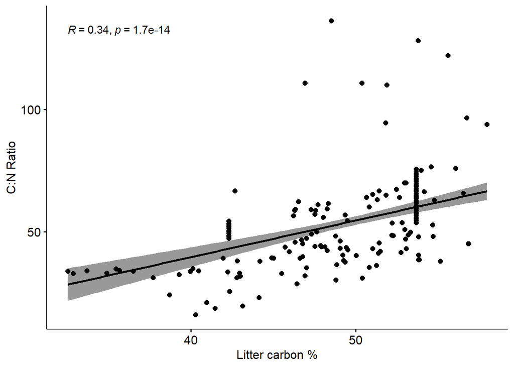

```r
library(ggplot2)
library("ggpubr")
ggscatter(litmeta, x = "Lit_Car", y = "Lit_Car_Nit_ratio",
          add = "reg.line", conf.int = TRUE,
          cor.coef = TRUE, cor.method = "pearson",
          xlab = "Litter carbon %", ylab = "C:N Ratio")
```

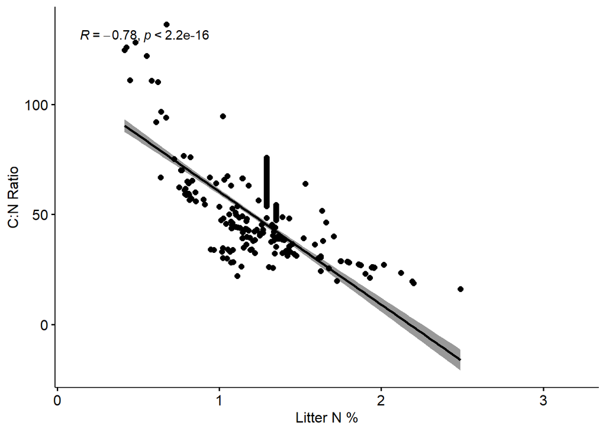

```r
cor1 <- cor.test(litmeta$Lit_Car, litmeta$Lit_Car_Nit_ratio,
                method = "pearson")
cor1
ggscatter(litmeta, x = "Lit_Nit", y = "Lit_Car_Nit_ratio",
          add = "reg.line", conf.int = TRUE,
          cor.coef = TRUE, cor.method = "pearson",
          xlab = "Litter N %", ylab = "C:N Ratio")
```

```r
cor2 <- cor.test(litmeta$Lit_Nit, litmeta$Lit_Car_Nit_ratio,  method="pearson")
cor2
```

[output not shown]